# Credit Risk Classification

Dedi Irwanto Samosir

05/01/2021

==================================================================

# Description

The purpose of this database is to provide information about a bank’s customers so that machine learning models can be developed that can predict whether a particular customer will repay the loan or not. We investigated 4 algorithms: Logistic Regression, Decision Tree, Random Forest, and Support Vector Machine (SVM).

The dataset used in this report is Credit Risk data in Kaggle. The dataset can be downloaded here. Link to dataset: https://www.kaggle.com/upadorprofzs/credit-risk

#### Variable Name Description Type

1. clientid = Client id Person
2. income = Income of the client
3. age = Age of client
4. loan = Load value
5. default = target 0 good client, 1 not.

#### Report Outline

1. Data Extraction
2. Exploratory Data Analysis
3. Data Preparation
4. Modeling
5. Evaluation
6. Recommendation

### 1. Data Extraction

The dataset is downloaded from Kaggle and saved in the data folder. We use **read.csv()** function to read the dataset and put in **CustomerCredit_df** data frame.

```r
CustomerCredit_df<-read.csv("C:/Users/dedis/Documents/Data Science Course/Portofolio/data/credit_risk.csv")
```

See the data dimension. The dataset has 2000 rows and 5 columns.

```r
dim(CustomerCredit_df)
```

```
## [1] 2000    5
```

### 2. Exploratory Data Analysis

To find out the column names and types, we used **str()** function.

```r
str(CustomerCredit_df)
```

```
## 'data.frame':    2000 obs. of  5 variables:
##  $ clientid: int  1 2 3 4 5 6 7 8 9 10 ...
##  $ income  : num  66156 34415 57317 42710 66953 ...
##  $ age     : num  59 48.1 63.1 45.8 18.6 ...
##  $ loan    : num  8107 6565 8021 6104 8770 ...
##  $ default : int  0 0 0 0 1 0 0 1 0 0 ...
```

**From the result above, we know the following:**  
1. The first column is **id**. It is unique and unnecessary for prediction. So, it should be removed.  
2. The fifth column is **default** Currently the type is **int** and it should be converted to **factor** and change variable name to be **payment_status**

```r
# remove unnecessary columns
CustomerCredit_df$clientid <- NULL

# change to factor for target variable
colnames(CustomerCredit_df)[4] <- "payment_status"
CustomerCredit_df$payment_status <- factor(CustomerCredit_df$payment_status,
                                           levels = c(0,1),
                                           labels = c("Paid", "Unpaid"))
```

#### 2.1. Univariate Data Analysis

Analysis of a single variable.  
Number of paid (P) and unpaid (UP) in **payment_status** column.

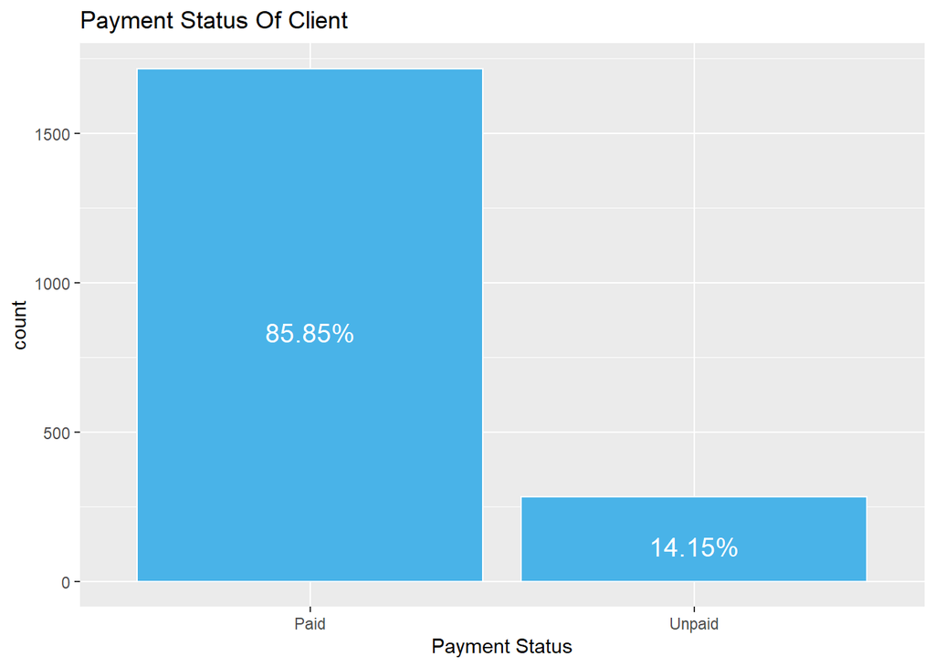

```r
library(ggplot2)
ggplot(data=CustomerCredit_df, aes(x=payment_status)) + geom_bar(color="white",fill = "#49B3E8")+
    geom_text(aes(y = ..count.. -50,label = paste0(round(prop.table(..count..),4) * 100, '%')),
              stat = 'count', position = position_stack(vjust=0.5), size = 5,color= "white") +
    labs(title="Payment Status Of Client", x="Payment Status")
```

From the result above, we know that the number of customer **Paid** is more than **Unpaid**.

Distribution of **loan** variable in Bar

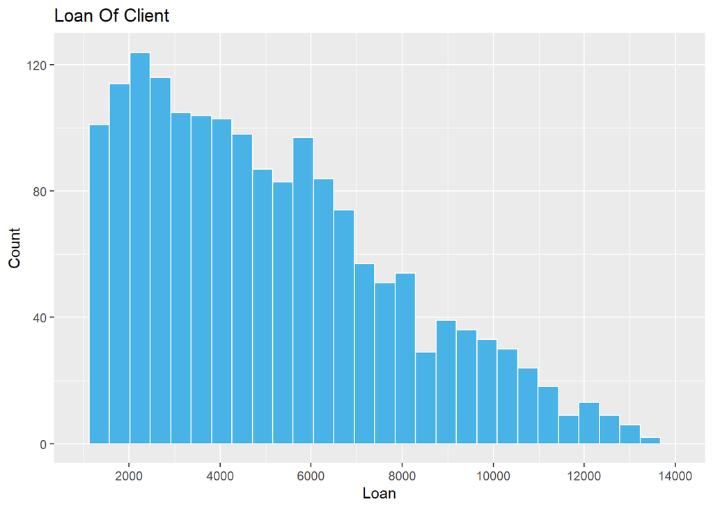

```r
ggplot(data=CustomerCredit_df, aes(x=loan))+
    geom_histogram(color="white",fill = "#49B3E8")+
    scale_x_continuous(breaks = c(0,2000,4000,6000,8000,10000,12000,14000),
                       labels = c("0","2000","4000","6000","8000","10000","12000",
                                  "14000"),
                       limits = c(1000,14000))+
    labs(title = "Loan Of Client",
         x="Loan", y="Count")
```

From the result above, we know that data distribution of **client loan** is uneven, it’s leaning more to the left

Distribution of **age** variable in Bar

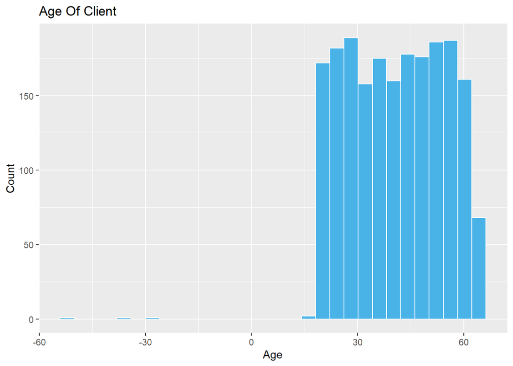

```r
ggplot(data=CustomerCredit_df, aes(x=age))+
    geom_histogram(color="white",fill = "#49B3E8")+
    labs(title = "Age Of Client",
         x="Age", y="Count")
```

Distribution of **income** variable in Bar

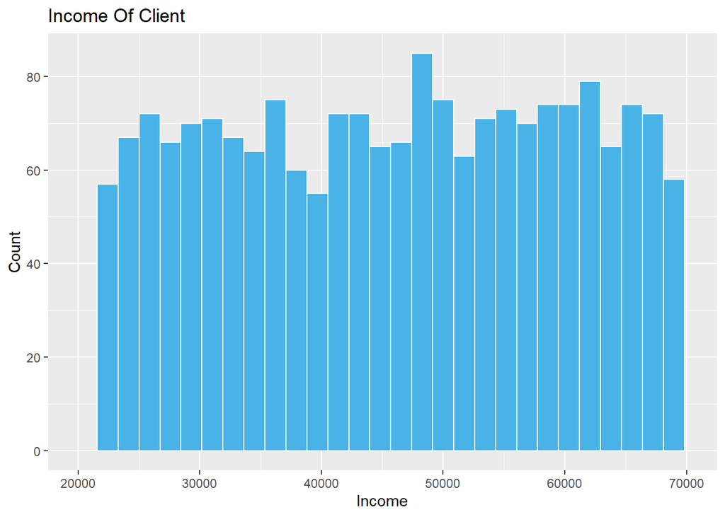

```r
ggplot(data=CustomerCredit_df, aes(x=income))+
    geom_histogram(color="white",fill = "#49B3E8")+
    scale_x_continuous(breaks = c(20000,30000,40000,50000
                                  ,60000,70000),
                       labels = c("20000","30000",
                                  "40000","50000","60000"
                                  ,"70000"),
                       limits = c(20000,70000))+
    labs(title = "Income Of Client",
         x="Income", y="Count")
```

#### 2.2. Bivariate Data Analysis

Analysis of two variables.  
Distribution of **loan** variable based on **payment_status**.

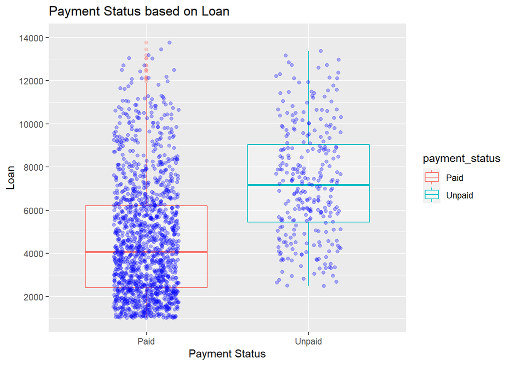

```r
ggplot(data=CustomerCredit_df, aes(x=payment_status,
                                        y=loan,
                                        color = payment_status)) +
    scale_y_continuous(breaks = c(0,2000,4000,6000,8000,10000,12000,14000),
                       labels = c("0","2000","4000","6000","8000","10000","12000",
                                  "14000"),
                       limits = c(1000,14000))+
    geom_boxplot(alpha=.3) +

    geom_jitter(alpha = 0.3,
                color = "blue",
                width = 0.2) +
    labs(title="Payment Status based on Loan",
         x="Payment Status", y="Loan")
```

**From the result above, we know the following:**  
1. Based on Loan , the number of paid is above 2000 and below 7000  
2. Based on Loan , the number of unpaid is is above 5000 and below 10000

Distribution of **income** variable based on **payment_status**.

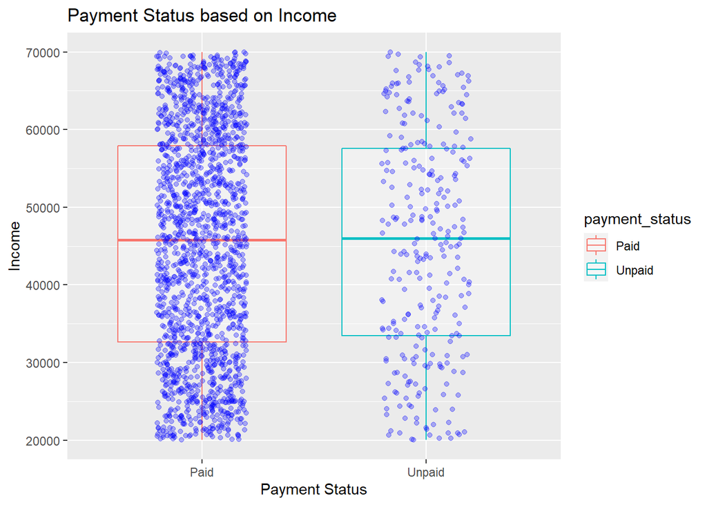

```r
ggplot(data=CustomerCredit_df, aes(x=payment_status,
                                        y=income,
                                        color = payment_status)) +
    scale_y_continuous(breaks = c(20000,30000,40000,50000
                                  ,60000,70000),
                       labels = c("20000","30000",
                                  "40000","50000","60000"
                                  ,"70000"),
                       limits = c(20000,70000))+
    geom_boxplot(alpha=.3) +
    geom_jitter(alpha = 0.3,
                color = "blue",
                width = 0.2) +
    labs(title="Payment Status based on Income",
         x="Payment Status", y="Income")
```

**From the result above, we know the following:**  
Based on Income of Customer, we see that customer who have a high salary or low salary has a potency to pay or unpaid their loan

Distribution of **age** variable based on **payment_status**.

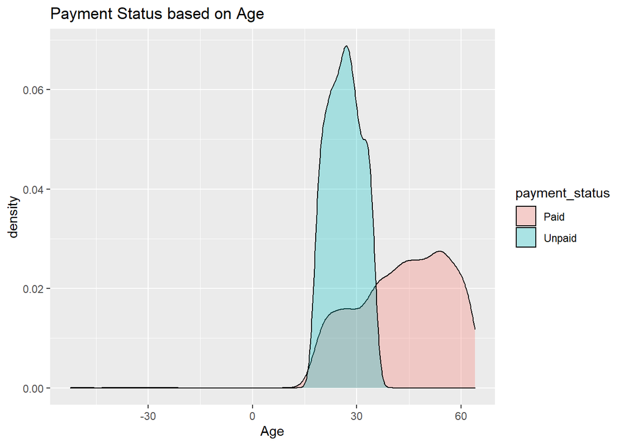

```r
ggplot(data=CustomerCredit_df, aes(x=age,
                                        fill=payment_status)) +
    geom_density(alpha=.3)+
    labs(title="Payment Status based on Age",
         x="Age")
```

#### 2.3. Multivariate Data Analysis

Compute and visualize correlation coefficient of each measurement.

Visualize Pearson’s Correlation Coefficient variables.

[figure not shown]

```r
library(corrgram)
corrgram(CustomerCredit_df[,c("income", "loan", "age")],
         main="Pearson’s Correlation Coefficient variables")
```

**From the result above, we know the following:**  
variable **income** has a strong corelation with variable **loan** than variable **age**

### 3. Data Preparation

#### 3.1 Feature Selection

```r
# remove unnecessary columns
# CustomerCredit_df$clientid <- NULL
```

#### 3.2 Remove Outlier

##### 3.2.1 Get Outliers Values

In this section, it is a part of getting the outliers value.

**Get Outliers Values**

```r
out_age <- boxplot.stats(CustomerCredit_df$age)$out
out_age
```

```
## [1] -28.21836 -52.42328 -36.49698
```

**Get Outliers Index**

```r
out_idx <- which(CustomerCredit_df$age %in% c(out_age))
out_idx
```

```
## [1] 16 22 27
```

**Data Without Outliers**

```r
CustomerCredit_clean <-CustomerCredit_df[-out_idx,]
dim(CustomerCredit_clean)
```

```
## [1] 1997    4
```

##### 3.2.2 Handling Missing Value

**Detect Missing Value on Data**

Distribution of Missing Value in Pattern

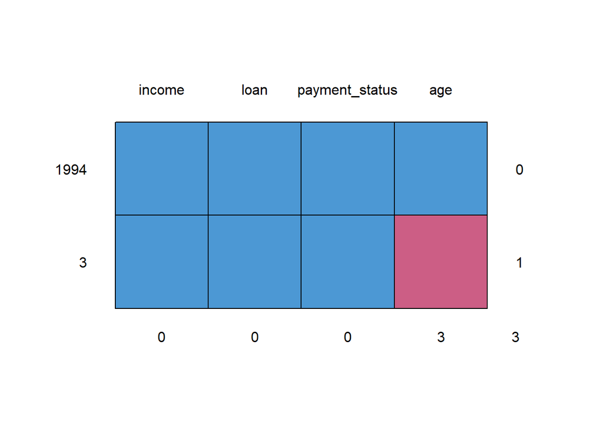

```
##      income loan payment_status age
## 1994      1    1              1   1 0
## 3         1    1              1   0 1
##           0    0              0   3 3
```

```r
library(mice)
md.pattern(CustomerCredit_clean)
```

**Imputation Missing Value With Mean**

```r
CustomerCredit_df.imput = CustomerCredit_clean
for(i in which(sapply(CustomerCredit_df.imput, is.numeric))){
    CustomerCredit_df.imput[is.na(CustomerCredit_df.imput[, i]), i] <- mean(CustomerCredit_df.imput[, i], na.rm = TRUE)
}
```

#### 3.3 Training and Test Division

```r
set.seed(2021)
m = nrow(CustomerCredit_df.imput)
train_ind <- sample(m, 0.8 * m)
TrainingSet <- CustomerCredit_df.imput[train_ind, ]
TestingSet <- CustomerCredit_df.imput[-train_ind, ]
```

### 4. Modelling

#### 4.1 Logistic Regression

```r
library(caret)
Model_LG <- train(payment_status ~ ., data = TrainingSet,
               method = "glm",
               na.action = na.omit,
               preProcess=c("scale","center"),
               trControl= trainControl(method="none")
)
summary(Model_LG)
```

```
##
## Call:
## NULL
##
## Deviance Residuals:
##      Min        1Q    Median        3Q       Max
## -2.26416  -0.08227  -0.00899  -0.00036   2.71212
##
## Coefficients:
##             Estimate Std. Error z value Pr(>|z|)
## (Intercept)  -7.6447     0.5937  -12.88   <2e-16 ***
## income       -3.6388     0.3460  -10.52   <2e-16 ***
## age          -4.7082     0.3880  -12.13   <2e-16 ***
## loan          5.3884     0.4544   11.86   <2e-16 ***
## ---
## Signif. codes:  0 '***' 0.001 '**' 0.01 '*' 0.05 '.' 0.1 ' ' 1
##
## (Dispersion parameter for binomial family taken to be 1)
##
##     Null deviance: 1316.55  on 1596  degrees of freedom
## Residual deviance:  360.52  on 1593  degrees of freedom
## AIC: 368.52
##
## Number of Fisher Scoring iterations: 9
```

```r
# Feature importance
print(varImp(Model_LG))
```

```
## glm variable importance
##
##        Overall
## age     100.00
## loan     82.88
## income    0.00
```

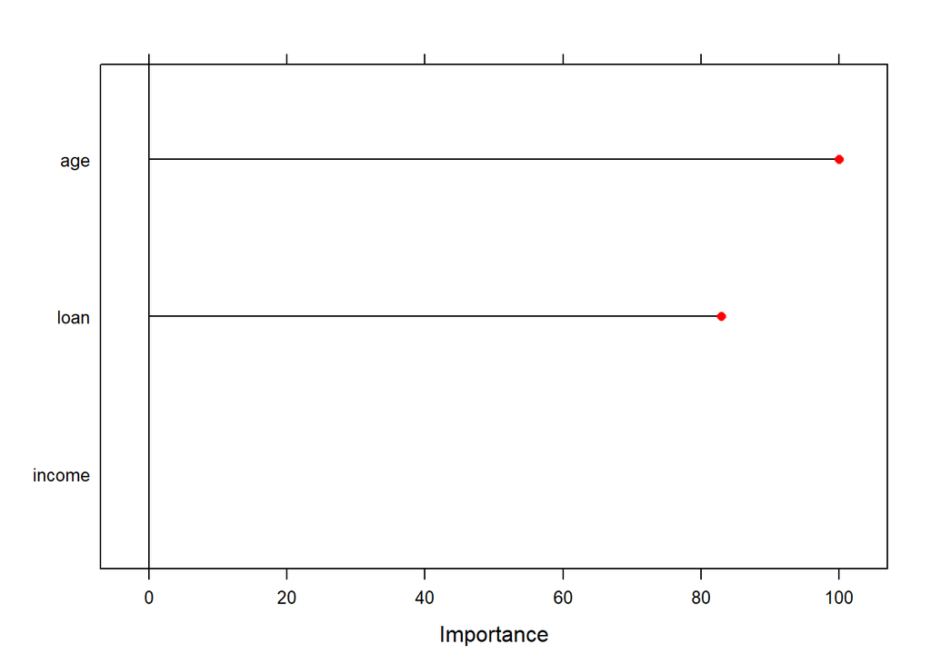

```r
Importance <- varImp(Model_LG)
plot(Importance, col = "red")
```

#### 4.2 Classification Tree

```r
library(party)
Model_CT <- train(payment_status ~ ., data = TrainingSet,
               method = "LMT",
               na.action = na.omit,
               preProcess=c("scale","center"),
               trControl= trainControl(method="none")
)
summary(Model_CT)
```

```
##
## === Summary ===
##
## Correctly Classified Instances        1594               99.8121 %
## Incorrectly Classified Instances         3                0.1879 %
## Kappa statistic                          0.9924
## Mean absolute error                      0.0481
## Root mean squared error                  0.0655
## Relative absolute error                 19.4711 %
## Root relative squared error             18.6587 %
## Total Number of Instances             1597
##
## === Confusion Matrix ===
##
##     a    b   <-- classified as
##  1365    2 |    a = Paid
##     1  229 |    b = Unpaid
```

```r
# Feature importance
print(varImp(Model_CT))
```

```
## ROC curve variable importance
##
##        Importance
## age        100.00
## loan        85.41
## income       0.00
```

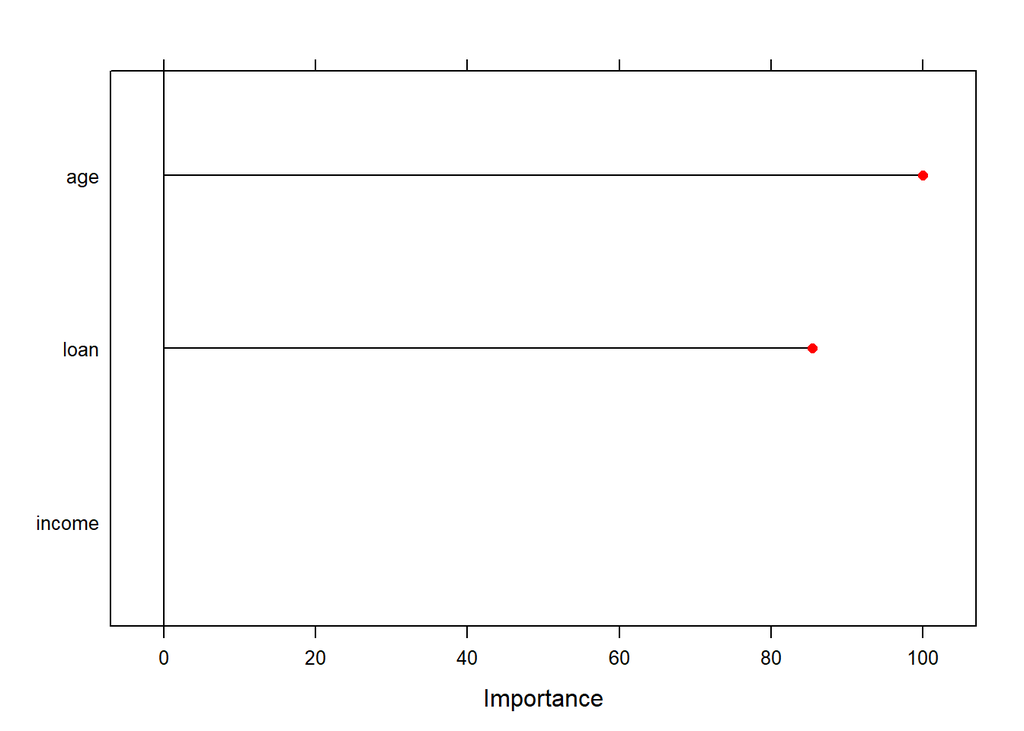

```r
Importance <- varImp(Model_CT)
plot(Importance, col = "red")
```

#### 4.3 Random Forest

```r
library(randomForest)
set.seed(2021)
fit.forest <- randomForest(formula = payment_status ~ .,
                           data = TrainingSet,
                           na.action = na.roughfix)
fit.forest
```

```
##
## Call:
##  randomForest(formula = payment_status ~ ., data = TrainingSet,      na.action = na.roughfix)
##                Type of random forest: classification
##                      Number of trees: 500
## No. of variables tried at each split: 1
##
##         OOB estimate of  error rate: 1.13%
## Confusion matrix:
##        Paid Unpaid class.error
## Paid   1363      4 0.002926116
## Unpaid   14    216 0.060869565
```

```r
summary(fit.forest)
```

```
##                 Length Class  Mode
## call               4   -none- call
## type               1   -none- character
## predicted       1597   factor numeric
## err.rate        1500   -none- numeric
## confusion          6   -none- numeric
## votes           3194   matrix numeric
## oob.times       1597   -none- numeric
## classes            2   -none- character
## importance         3   -none- numeric
## importanceSD       0   -none- NULL
## localImportance    0   -none- NULL
## proximity          0   -none- NULL
## ntree              1   -none- numeric
## mtry               1   -none- numeric
## forest            14   -none- list
## y               1597   factor numeric
## test               0   -none- NULL
## inbag              0   -none- NULL
## terms              3   terms  call
```

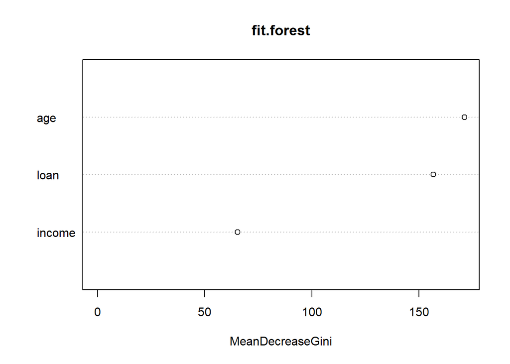

```r
# Feature importance
varImpPlot(fit.forest)
```

#### 4.4 Support Vector Machine

```r
library(e1071)
library(caret )


Model_SVM <-   train(payment_status ~ ., data = TrainingSet,
               method = "svmPoly",
               na.action = na.omit,
               preProcess=c("scale","center"),
               trControl= trainControl(method="none"),
               tuneGrid = data.frame(degree=1,scale=1,C=1)
)

summary(Model_SVM)
```

```
## Length  Class   Mode
##      1   ksvm     S4
```

```r
# Feature importance
print(varImp(Model_SVM))
```

```
## ROC curve variable importance
##
##        Importance
## age        100.00
## loan        85.41
## income       0.00
```

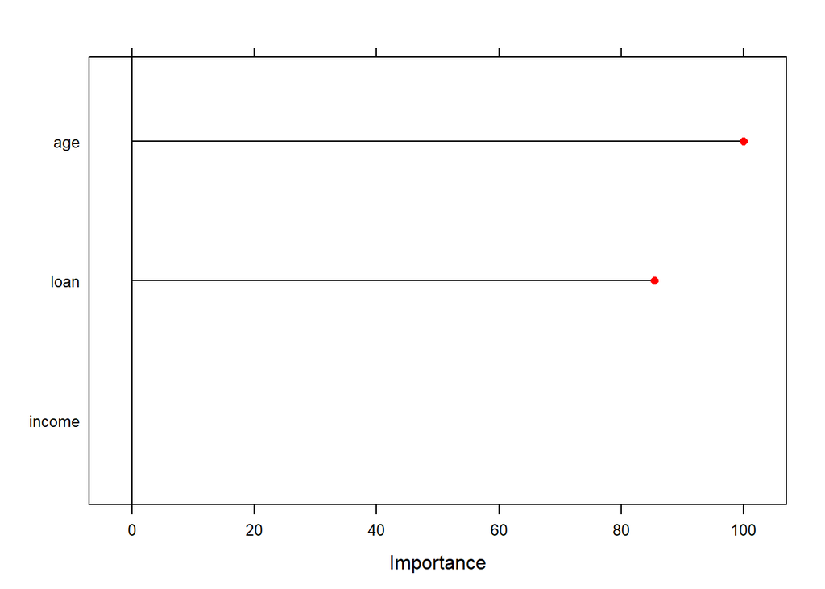

```r
Importance <- varImp(Model_SVM)
plot(Importance, col = "red")
```

### 5. Evaluate The Model

#### 5.1 Logistic Regression

```r
Model.Testing.LG <- predict(Model_LG, TestingSet)
Model.testing.confusion.LG <-confusionMatrix(Model.Testing.LG,                                         TestingSet$payment_status,
                                             dnn = c("Predict","Actual"))
Model.testing.confusion.LG
```

```
## Confusion Matrix and Statistics
##
##         Actual
## Predict  Paid Unpaid
##   Paid    336      8
##   Unpaid   11     45
##
##                Accuracy : 0.9525
##                  95% CI : (0.9268, 0.9712)
##     No Information Rate : 0.8675
##     P-Value [Acc > NIR] : 1.362e-08
##
##                   Kappa : 0.7982
##
##  Mcnemar's Test P-Value : 0.6464
##
##             Sensitivity : 0.9683
##             Specificity : 0.8491
##          Pos Pred Value : 0.9767
##          Neg Pred Value : 0.8036
##              Prevalence : 0.8675
##          Detection Rate : 0.8400
##    Detection Prevalence : 0.8600
##       Balanced Accuracy : 0.9087
##
##        'Positive' Class : Paid
##
```

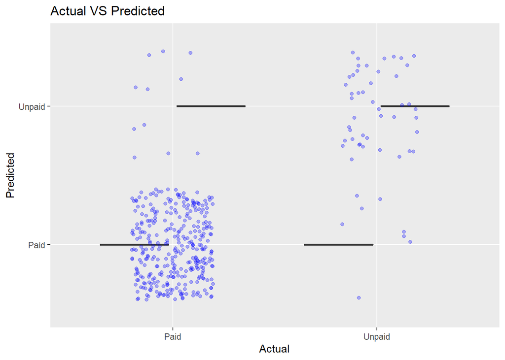

```r
ggplot(data=TestingSet, aes(x=payment_status,
                                   y=Model.Testing.LG)) +

    geom_boxplot(alpha=.3) +

    geom_jitter(alpha = 0.3,
                color = "blue",
                width = 0.2) +
    labs(title="Actual VS Predicted",
         x="Actual", y="Predicted")
```

#### 5.2 Support Vector Machine

```r
Model.Testing.SV <- predict(Model_SVM, TestingSet)
Model.testing.confusion <-confusionMatrix(Model.Testing.SV,
                                   TestingSet$payment_status)
Model.testing.confusion
```

```
## Confusion Matrix and Statistics
##
##           Reference
## Prediction Paid Unpaid
##     Paid    335      8
##     Unpaid   12     45
##
##                Accuracy : 0.95
##                  95% CI : (0.9238, 0.9692)
##     No Information Rate : 0.8675
##     P-Value [Acc > NIR] : 4.066e-08
##
##                   Kappa : 0.7892
##
##  Mcnemar's Test P-Value : 0.5023
##
##             Sensitivity : 0.9654
##             Specificity : 0.8491
##          Pos Pred Value : 0.9767
##          Neg Pred Value : 0.7895
##              Prevalence : 0.8675
##          Detection Rate : 0.8375
##    Detection Prevalence : 0.8575
##       Balanced Accuracy : 0.9072
##
##        'Positive' Class : Paid
##
```

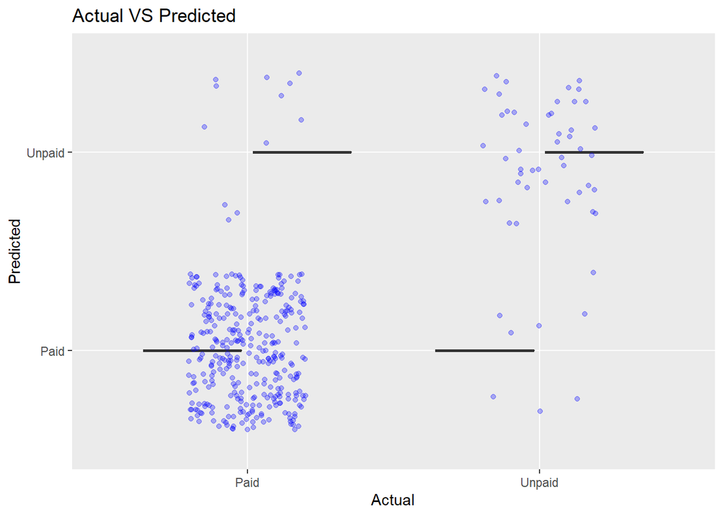

```r
ggplot(data=TestingSet, aes(x=payment_status,
                            y=Model.Testing.SV)) +

    geom_boxplot(alpha=.3) +

    geom_jitter(alpha = 0.3,
                color = "blue",
                width = 0.2) +
    labs(title="Actual VS Predicted",
         x="Actual", y="Predicted")
```

#### 5.3 Random Forest

```r
Model.Testing.RF <- predict(fit.forest, TestingSet)
Model.testing.confusion <-confusionMatrix(Model.Testing.RF,
                                          TestingSet$payment_status)
Model.testing.confusion
```

```
## Confusion Matrix and Statistics
##
##           Reference
## Prediction Paid Unpaid
##     Paid    347      3
##     Unpaid    0     50
##
##                Accuracy : 0.9925
##                  95% CI : (0.9782, 0.9985)
##     No Information Rate : 0.8675
##     P-Value [Acc > NIR] : <2e-16
##
##                   Kappa : 0.9666
##
##  Mcnemar's Test P-Value : 0.2482
##
##             Sensitivity : 1.0000
##             Specificity : 0.9434
##          Pos Pred Value : 0.9914
##          Neg Pred Value : 1.0000
##              Prevalence : 0.8675
##          Detection Rate : 0.8675
##    Detection Prevalence : 0.8750
##       Balanced Accuracy : 0.9717
##
##        'Positive' Class : Paid
##
```

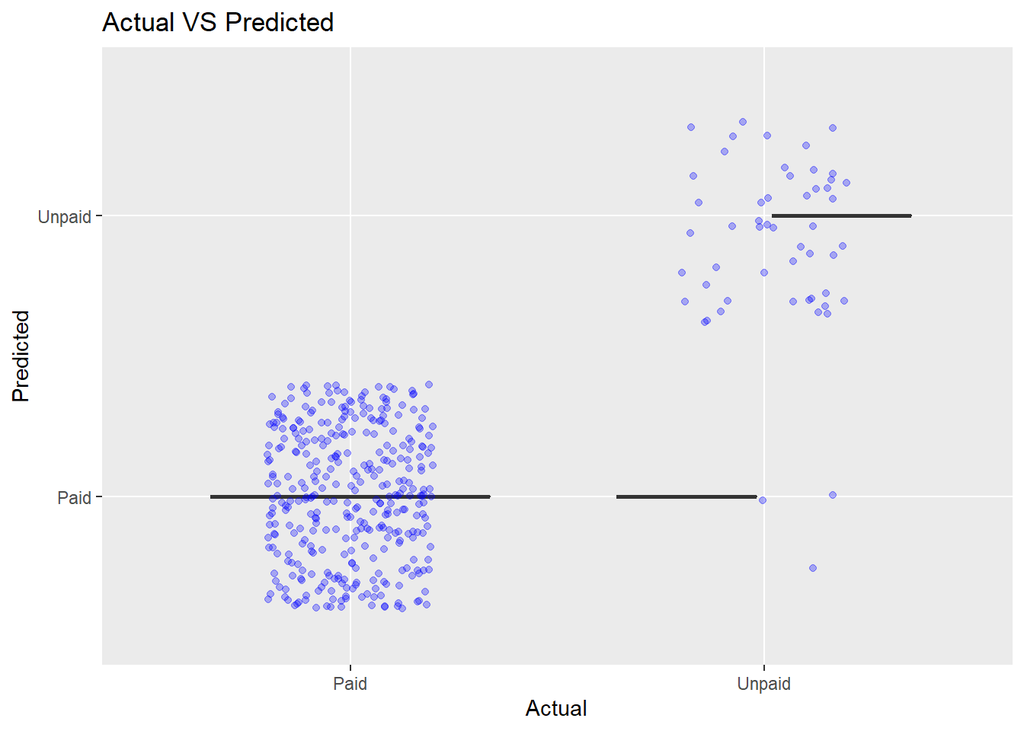

```r
ggplot(data=TestingSet, aes(x=payment_status,
                            y=Model.Testing.RF)) +

    geom_boxplot(alpha=.3) +

    geom_jitter(alpha = 0.3,
                color = "blue",
                width = 0.2) +
    labs(title="Actual VS Predicted",
         x="Actual", y="Predicted")
```

#### 5.4 Classification Tree

```r
Model.Testing.CT <- predict(Model_CT, TestingSet)
Model.testing.confusion <-confusionMatrix(Model.Testing.CT,
                                          TestingSet$payment_status)
Model.testing.confusion
```

```
## Confusion Matrix and Statistics
##
##           Reference
## Prediction Paid Unpaid
##     Paid    346      1
##     Unpaid    1     52
##
##                Accuracy : 0.995
##                  95% CI : (0.9821, 0.9994)
##     No Information Rate : 0.8675
##     P-Value [Acc > NIR] : <2e-16
##
##                   Kappa : 0.9783
##
##  Mcnemar's Test P-Value : 1
##
##             Sensitivity : 0.9971
##             Specificity : 0.9811
##          Pos Pred Value : 0.9971
##          Neg Pred Value : 0.9811
##              Prevalence : 0.8675
##          Detection Rate : 0.8650
##    Detection Prevalence : 0.8675
##       Balanced Accuracy : 0.9891
##
##        'Positive' Class : Paid
##
```

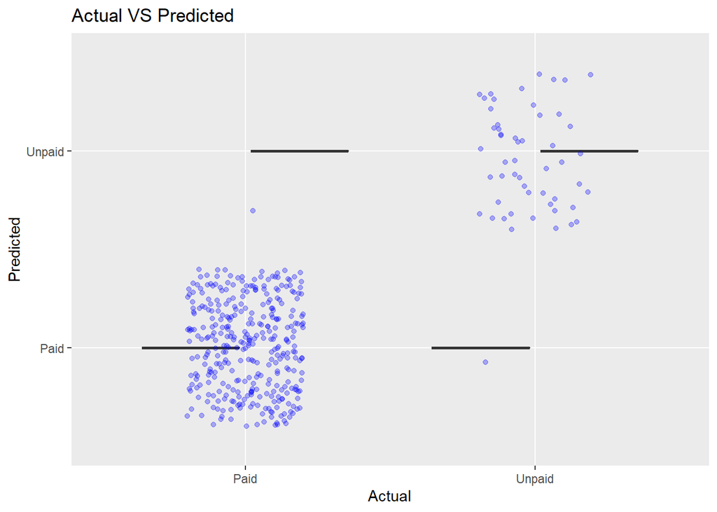

```r
ggplot(data=TestingSet, aes(x=payment_status,
                            y=Model.Testing.CT)) +

    geom_boxplot(alpha=.3) +

    geom_jitter(alpha = 0.3,
                color = "blue",
                width = 0.2) +
    labs(title="Actual VS Predicted",
         x="Actual", y="Predicted")
```

### 6. Reccomendation

**From the result above, we know the following:**  
1. Classification Tree is the best among all the tested algortihms  
2. Based Classification Tree Model , the most important variables are age, loan and income  
3. For age around 25 to 30 the value of the loan may be lowered The results can be improved by better data preparation